# Typy danych

dr Magdalena Guzowska

## Rozkłady, generowanie liczb losowych z rozkładów

W biologii wszelkie zmienne będące pomiarami jakiejś wielkości, oceną doświadczeń czy obserwacji, mają jakiś rozkład. Dotyczy to całości zjawiska w całej populacji. Przykładem może być wynik jakiegoś eksperymentu, który powtarzamy w takich samych warunkach i którego konkretny wynik powtarza się średnio z częstością p. Przyroda i warunki przeprowadzania tego eksperymentu określają tu prawdopodobieństwo uzyskania tego wyniku, czyli taką proporcję tych wyników, jaką uzyskalibyśmy po powtórzeniu tego eksperymentu nieskończenie wiele razy.

**Każda zmienna dla określonej populacji statystycznej ma jeden, jednoznacznie określony rozkład.**

**Populacje statystyczne są nieskończone. Obejmują osobniki/obiekty/eksperymenty istniejące i mogące zaistnieć.**

Zmienną jest wielkość, która może mieć wiele różnych wartości dla różnych obiektów w populacji. Zmienne mają wartości dla wszystkich elementów populacji statystycznej, choć nie wszystkie możemy zmierzyć. Zmienne dzielą się na dyskretne (mające skończony lub przeliczalny zbiór wartości jakościowych lub liczbowych), ciągłe (o zbiorze wartości będących przedziałem liczbowym) i złożone (wyniki eksperymentu notowane co minutę, tzw. szeregi czasowe, krzywe wzrostu osobnika itd.). Alternatywnie zmienne dzielimy na liczbowe i nieliczbowe. Wartości zmiennych nieliczbowych na ogół nie porządkujemy, nie wyliczamy średniej itp.

1. zmienne dyskretne jakościowe o wartościach nieuporządkowanych (np. płeć, kolor oczu)
2. zmienne dyskretne jakościowe o wartościach uporządkowanych (np. ocena wybierana z zestawu {niedostateczny, dostateczny, minimalny, dobry, bardzo dobry, wybitny})
3. zmienne dyskretne liczbowe (np. liczba odnóży u stonogi)
4. zmienne ciągłe (są to tylko zmienne liczbowe, na ogół skalarne, czyli wyliczane w jednostkach)
5. zmienne złożone

Rozkład zmiennych to rodzaj uporządkowania wartości tych zmiennych. Jest to takie uporządkowanie, na podstawie którego można wyciągać wnioski dotyczące funkcjonowania przyrody. Dotyczy wszystkich zmiennych, nawet jakościowych o ile uporządkuje się jakoś, choćby sztucznie, ich zbiór wartości.

### Rodzaje rozkładów

Dla zmiennych dyskretnych rozkład jest to przyporządkowanie każdej wartości zmiennej prawdopodobieństwa jej pojawienia się w danych warunkach środowiska. To prawdopodobieństwo jest równe frakcji osobników o danej wartości zmiennej. Rozkład przedstawia się najczęściej w postaci histogramu, gdzie na osi poziomej zaznacza się wartości zmiennej, a na osi pionowej prawdopodobieństwa ich pojawienia się. Suma wysokości słupków na takim wykresie jest równa 1.

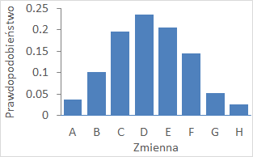

Funkcją rozkładu nazywamy funkcję, która każdej wartości zmiennej przyporządkowuje prawdopodobieństwo pojawienia się tej zmiennej w rzeczywistości. Jej wykresem jest rozkład mający postać histogramu.

Dla zmiennych ciągłych możliwe do uzyskania wartości należą do jakiegoś przedziału liczb rzeczywistych. Wielkość, do której zmierzają histogramy, gdy długość przedziału histogramowania zmierza do zera, jest pewną krzywą zwaną gęstością rozkładu zmiennej X. Prawdopodobieństwo, że jakaś wartość zmiennej jest większa od x1 i mniejsza od x2, jest równe polu powierzchni pionowego pasa wyprowadzonego z odcinka [x1,x2] i znajdującego się pod gęstością rozkładu zmiennej.

Rozkłady próby zaimplementowano do R pod nazwami:

- beta - rozkład beta
- binom - rozkład dwumianowy
- cauchy - rozkład Cauchy’ego
- chisq - rozkład chi-kwadrat
- exp - rozkład wykładniczym
- f - rozkład F
- gamma - rozkład gamma
- geom - rozkład geometryczny
- lnorm - rozkład log-normalny
- logis - rozkład logistyczny
- nbinom - rozkład ujemny dwumianowy
- norm - rozkład normalny
- pois - rozkład Poissona
- signrank - rozkład statystyk testu znakowanych rank Wilcoxona
- t - rozkład studenta
- unif - rozkład jednostajny
- weibull - rozkład Weibulla

### Dystrybuanta, funkcja i gęstość rozkładu

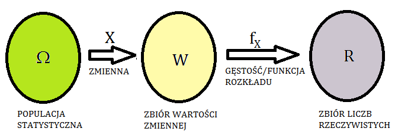

Pojęcia rozkładu definiowane są w rachunku prawdopodobieństwa jako przestrzenie probabilistyczne, które można określić dla zmiennych losowych działających ze zbioru zdarzeń do zbioru dyskretnego (skończonego lub przeliczalnego) albo zbioru lub podzbioru liczb rzeczywistych. Prawdopodobieństwo związane jest z losowaniem osobnika/obiektu z populacji. Biolodzy zawsze mają pierwotną przestrzeń probabilistyczną: populację i określony sposób pobierania próby z tej populacji. Biolodzy zawsze mają zmienną - wielkość pomiarową. Dopiero dla niej wyznaczają rozkłady. W biologii rozkłady bez zmiennych nie istnieją.

Dystrybuanty są funkcjami niemalejącymi. Dla rozkładu dyskretnego przedstawia się je w postaci słupków rosnących do 1, dla rozkładów ciągłych w postaci funkcji esowatej biegnącej od 0 do 1.

##### Wartości gęstości rozkładu

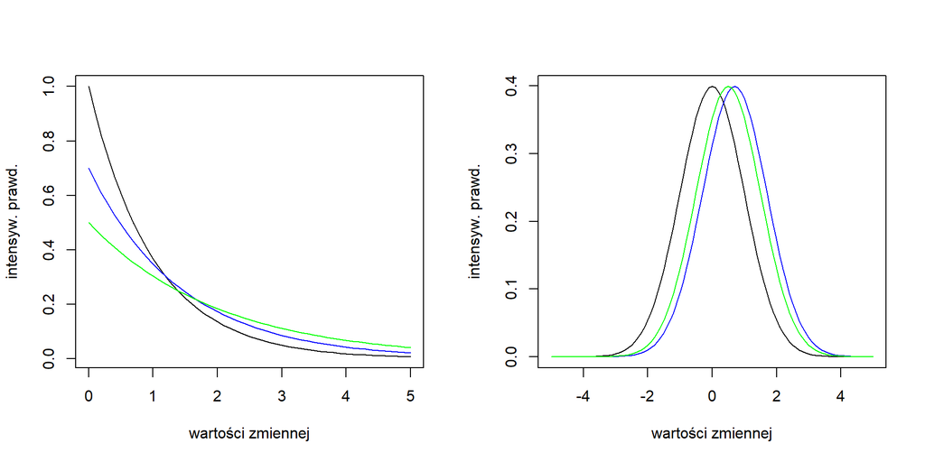

```r
par(mfrow=c(1,2))
plot(0:50/10,dexp(0:50/10),type="l",xlab="wartości zmiennej",ylab="intensyw. prawd.")
lines(0:50/10,dexp(0:50/10,0.7),col="blue")
lines(0:50/10,dexp(0:50/10,0.5),col="green")

plot(-50:50/10,dnorm(-50:50/10),xlim=c(-5,5), type="l",xlab="wartości zmiennej",ylab="intensyw. prawd.")
lines(-50:50/10,dnorm(-50:50/10,0.7),xlim=c(-5,5), col="blue")
lines(-50:50/10,dnorm(-50:50/10,0.5),xlim=c(-5,5), col="green")
```

##### Wartość dystrybuanty

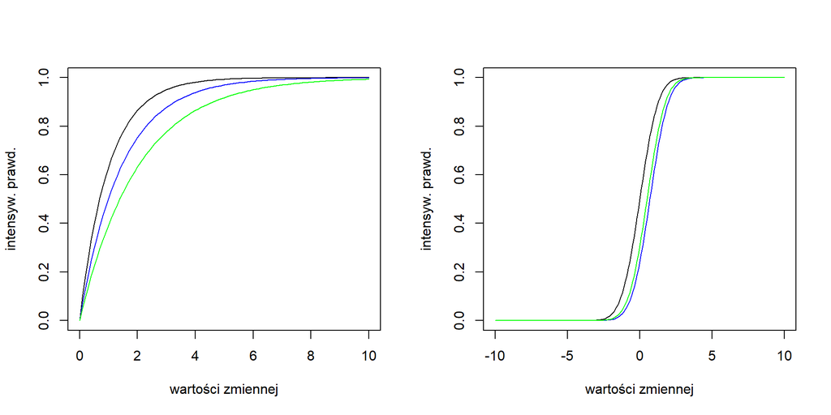

```r
par(mfrow=c(1,2))
plot(0:100/10,pexp(0:100/10),type="l",xlab="wartości zmiennej",ylab="intensyw. prawd.")
lines(0:100/10,pexp(0:100/10,0.7),col="blue")
lines(0:100/10,pexp(0:100/10,0.5),col="green")

plot(-100:100/10,pnorm(-100:100/10),type="l",xlab="wartości zmiennej",ylab="intensyw. prawd.")
lines(-100:100/10,pnorm(-100:100/10,0.7),col="blue")
lines(-100:100/10,pnorm(-100:100/10,0.5),col="green")
```

## Charakterystyki rozkładu i charakterystyki rozkładu z próby

Zmienne, których wartościami nie są liczby, mają rozkłady dyskretne, które porównuje się tylko ze sobą patrząc na wysokość słupków określonych dla tej samej wartości. Porównywanie rozkładów zmiennych o wartościach liczbowych ma bardziej rozbudowaną strukturę. Liczby mają określoną relację nierówności i często można, przyglądając się rozkładom ocenić, która populacja cechuje się większymi wartościami zmiennej, większym zakresem zmienności wartości itp. Najbardziej typową oceną rozkładów liczbowych jest ich przesunięcie względem siebie. O rozkładzie przesuniętym w kierunku większych wartości mówimy że obrazuje obiekty/ osobniki pod jakimś względem większe. Sposobem na ocenę rozkładów zmiennych liczbowych, a więc wszystkich zmiennych ciągłych i wielu dyskretnych, stały się pewne liczby nazywane czasami (całkiem błędnie) miarami, poprawniej ocenami, poprawnie - **charakterystykami rozkładów**.

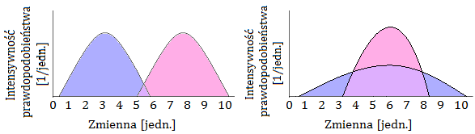

Najczęściej używanymi charakterystykami rozkładów w biologii są:

1. Charakterystyki tendencji centralnej
- Wartość oczekiwana
- Mediana
- Wartość modalna
2. Charakterystyki zmienności
- Zakres
- Wariancja
- Odchylenie standardowe
- Odchylenie przeciętne
- Odchylenie ćwiartkowe
3. Charakterystyki skośności
- Wsp. zmienności
- Pozycyjny wsp. zmienności
4. Inne
- Minimum
- Maksimum
- Kwartyle, pentyle i inne kwantyle

Najbardziej znanymi charakterystykami rozkładu, za pomocą których oceniamy, gdzie zmienna przyjmuje mniejsze, a gdzie większe wartości, są **mediana** i **wartość oczekiwana**. Mediana ma łatwą interpretację geometryczną. Jest to taka liczba (odczytywana na osi poziomej, a więc wyrażana w tych samych jednostkach, co zmienna), dla której połowa obiektów populacji ma wartość zmiennej mniejszą, a połowa większą.

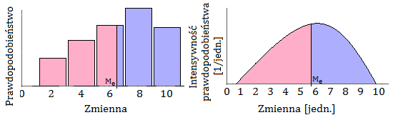

Wartość oczekiwana jest wielkością jednoznacznie określoną dla prawie wszystkich rozkładów (czasem dla bardzo skośnych rozkładów ma wartość nieskończoną i tylko dla niesymetrycznych rozkładów bardzo skośnych na lewo i na prawo może mieć wartość nieokreśloną).

Skończone ciągi pomiarów zaczęto charakteryzować średnią.

$\LARGE \bar x = \frac{\displaystyle\sum_{i=1}^{n} x_i}{n}$

Odpowiednik tej wielkości, wyliczony dla nieskończenie wielu liczb losowanych spod obszaru znajdującego się pod gęstością rozkładu.

$\LARGE EX = \int_{x_{min}}^{x_{max}} xf_x(x)dx$

gdzie X jest zmienną, EX - wartością oczekiwaną, $X_{min}$ - minimalną wartością zmiennej, $x_{max}$ wartością maksymalną zmiennej, $f_X$ gęstością rozkładu zmiennej, x kolejnymi wartościami zmiennej wybieranymi z zakresu [$x_{min}, x_{max}$] podczas całkowania.

Najpopularniejszą charakterystyką rozrzutu danych jest odchylenie standardowe

$\LARGE sd(X) = \sqrt\frac{\displaystyle\sum_{i=1}^{n}(x_i-\bar x)^2}{n-1}$

Odchylenie standardowe jest ściśle związane z wartością oczekiwaną. Wyliczane jest, gdy tendencje centralne rozkładu, charakteryzuje się za pomocą średnich. Gdy dla danych wylicza się medianę, lepiej jest użyć odchylenia ćwiartkowego - różnicy między trzecim a pierwszym kwartlem.

W R medianę i rozklad ćwiartkowy można wyliczyć korzystając z zaimplementowanych funkcji rozkładów i następujących zależności:

**MEDIANA:** q“nazwa rozkładu”(0.5)

**ODCHYLENIE ĆWIARTKOWE:** q“nazwa rozkładu”(0.75) - q“nazwa rozkładu”(0.25)

Dla n-elementowych prób liczb losowanych z tego samego rozkładu obie charakterystyki są wyliczane dla dowolnych wektorów za pomocą funkcji `mean` i `median`.

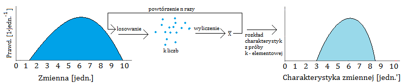

Po bardzo wielu (nieskończenie wielu) losowaniach kolejnych prób i wyliczeniach charakterystyki nowy rozkład będzie określony jednoznacznie.

Rozkład średnich z prób n-elementowych losowanych z rozkładu normalnego

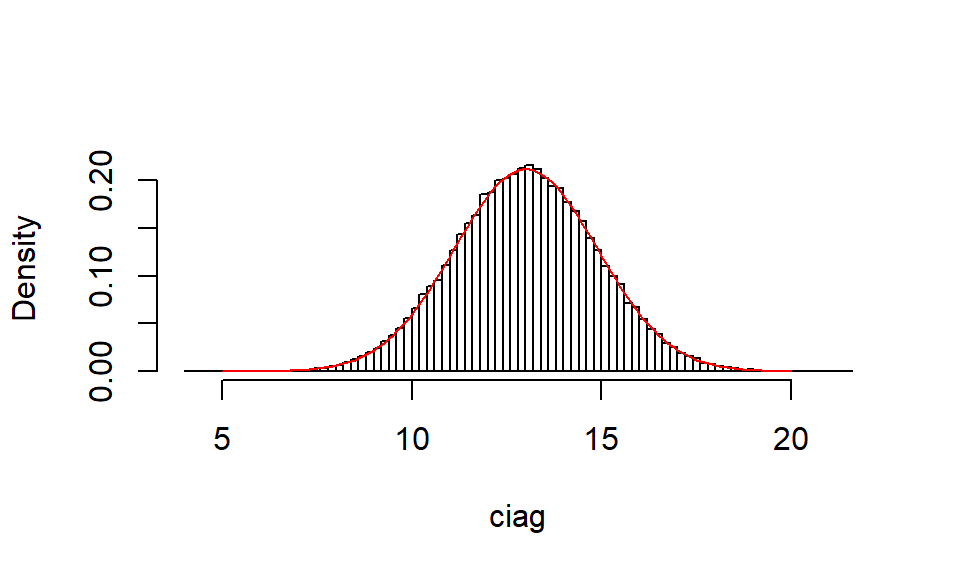

W 1908 roku William Gosset (publikujący pod pseudonimem Student) wyprowadził wzór dla gęstość rozkładu wielkości wyliczanych z n-elementowej próby losowanej z rozkładu normalnego standaryzowanego za pomocą następującego wzoru:

$\LARGE \Psi(x_1,...,x_n) = \frac{\bar x}{s} \sqrt{n}$, gdzie $\LARGE s=\sqrt{\frac{\displaystyle\sum_{i=1}^{n}(x_i - \bar x)^2}{n-1}}$

Jest to rozkład *t*-Studenta - właściwie rodzina rozkładów, zależna od liczby naturalnej df zwanej stopniami swobody.

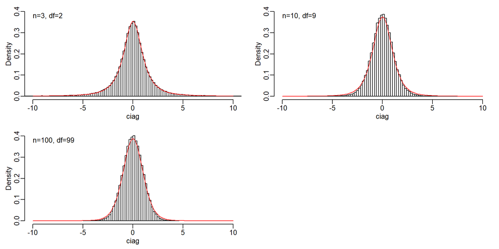